# 191024_Class08

Mark Allan Co Jacob

10/24/2019

# **Intro to Machine Learning**

We will be conducting unsupervised machine learning. We first need to understand what k-mean clustering means. If we define k as a numerical value, we are specifying how many ‘clusters’ we are looking for. We want to calculate the mean values in the clusters of observation. We also want to consider the variance of these clusters. The variance can be considered as an indicator of clustering quality. The smaller the variance, the better the clustering quality. If we want to stay in one-dimension data, we can just use means. In a two-dimension data set, we need to use the euclidian equation.

In R, we will be utilizing the command : kmeans( x = , centers = 3 , nstart = 20) x is the provided data you want to observe. centers are the amount of clusters you desire. nstart is the amount of iterations of cycles you want R to parse through your data. It is important to note that k-means is random. It can start its iterations at random points. The smallest sum-square is the best answer. However, it is up to us to define the best number of clusters to expect.

To determine the number of clusters, we should NOT look to trial and error. We can use a scree plot. With a scree plot, we can find the quickest gain without sacrificing too much time.

## Working through a k-means process

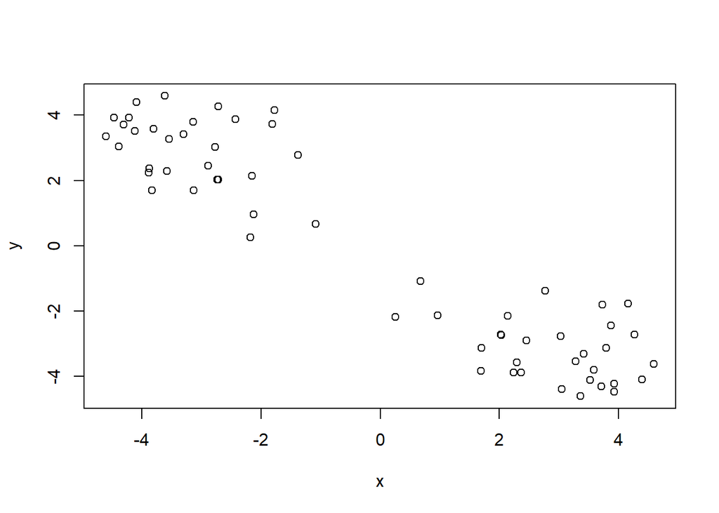

```r
tmp <- c(rnorm(30,-3), rnorm(30,3))
# rnorm takes 30 points and centers them around x = -3, same goes for the second element of tmp.
x <- cbind(x=tmp, y=rev(tmp))
plot(x)
```

```r
# Actually using the k-means command

k <- kmeans(x, centers =2, nstart = 20)
```

Looking into the output of kmeans

There are 30 points within the clusters.

```r
k
```

```
## K-means clustering with 2 clusters of sizes 30, 30
##
## Cluster means:
##           x         y
## 1 -3.156158  2.906980
## 2  2.906980 -3.156158
##
## Clustering vector:
##  [1] 1 1 1 1 1 1 1 1 1 1 1 1 1 1 1 1 1 1 1 1 1 1 1 1 1 1 1 1 1 1 2 2 2 2 2
## [36] 2 2 2 2 2 2 2 2 2 2 2 2 2 2 2 2 2 2 2 2 2 2 2 2 2
##
## Within cluster sum of squares by cluster:
## [1] 64.85548 64.85548
##  (between_SS / total_SS =  89.5 %)
##
## Available components:
##
## [1] "cluster"      "centers"      "totss"        "withinss"
## [5] "tot.withinss" "betweenss"    "size"         "iter"
## [9] "ifault"
```

```r
# k$size indicates the points in each cluster
k$size
```

```
## [1] 30 30
```

```r
# k$cluster indicates the points assigned to the allotted clusters. The clustering vector output if the output of kmeans is printed.
k$cluster
```

```
##  [1] 1 1 1 1 1 1 1 1 1 1 1 1 1 1 1 1 1 1 1 1 1 1 1 1 1 1 1 1 1 1 2 2 2 2 2
## [36] 2 2 2 2 2 2 2 2 2 2 2 2 2 2 2 2 2 2 2 2 2 2 2 2 2
```

```r
# k$center indicates the coordinates of the center of the clusters.
k$centers
```

```
##           x         y
## 1 -3.156158  2.906980
## 2  2.906980 -3.156158
```

Let’s see if we can plot these clusters with differentiating colors.

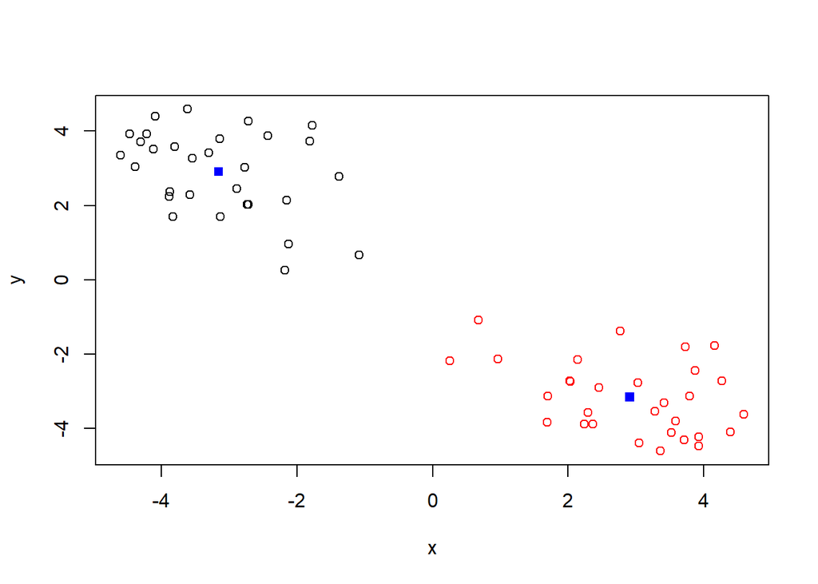

```r
# Using k$cluster as a color specification. The points assigned to 1 will be assigned as black and 2 will be red.

plot(x, col=k$cluster)

# To add center points, recall k$centers
points(k$centers, col="blue", pch= 15)
```

As good a function kmeans is, it has its limitations: 1. Constantly have to specify parameters 2. Depends on iterations for quality

## **Hierarchical Clustering**

We can use other clustering algorithms in which it defines everything as a cluster and works its way up in clustering until it ends up with one.

Working through the hierarchical clustering process: hclust() Note: You must specify distance matrix as input. wWe can specify fwith the dist() function.

```r
# First we need to calculate point (dis)similarity
# as the Euclidean distance between observations
dist_matrix <- dist(x)
# The hclust() function returns a hierarchical
# clustering model
hc <- hclust(d = dist_matrix)
# the print method is not so useful here
hc
```

```
##
## Call:
## hclust(d = dist_matrix)
##
## Cluster method   : complete
## Distance         : euclidean
## Number of objects: 60
```

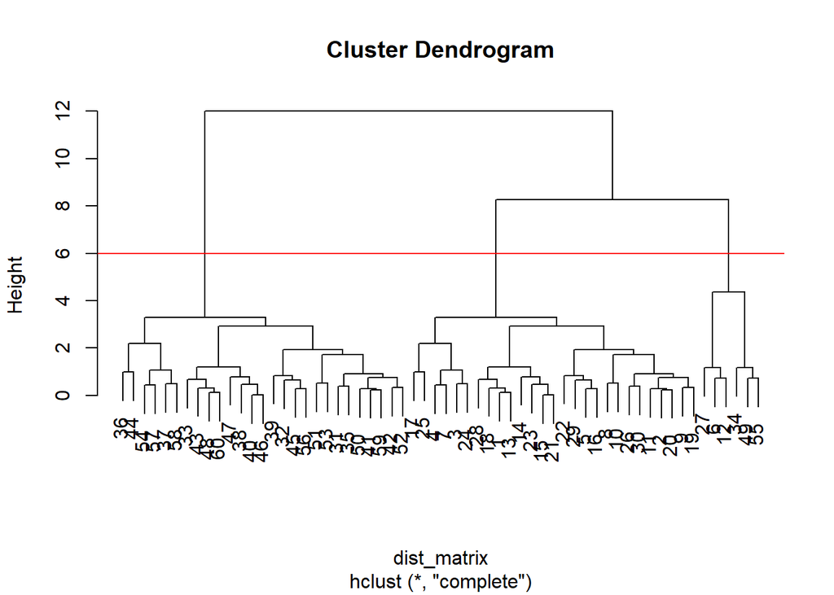

```r
plot(hc)

#Interestingly enough, we can see the data point entries labelled in the 'leaves' of this data tree.

# We can specify height (the limit to the clustering) by cutting it and the distance between clusters.
plot(hc)
abline(h=6, col= "red")
```

```r
grp <- cutree(hc, h=6)
# cutree() gives us the membership factor after a certain height cutoff.

#Different types of hierarchical clustering : complete, single, center
```

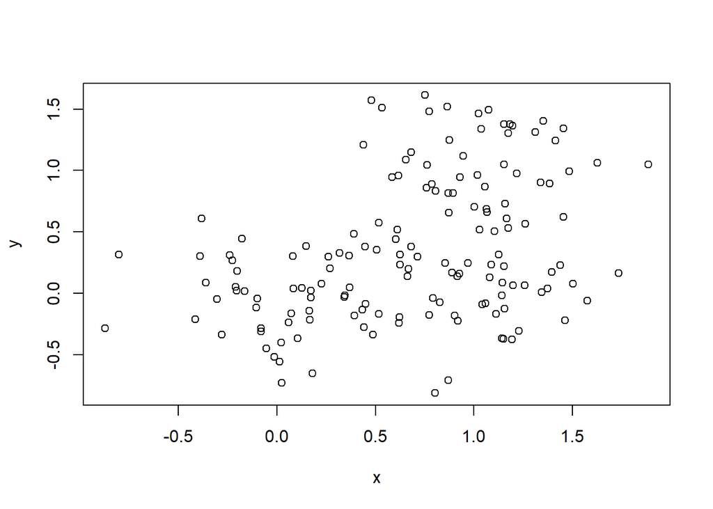

```r
# Step 1. Generate some example data for clustering
x <- rbind(
 matrix(rnorm(100, mean=0, sd = 0.3), ncol = 2), # c1
 matrix(rnorm(100, mean = 1, sd = 0.3), ncol = 2), # c2
 matrix(c(rnorm(50, mean = 1, sd = 0.3), # c3
 rnorm(50, mean = 0, sd = 0.3)), ncol = 2))
colnames(x) <- c("x", "y")
# Step 2. Plot the data without clustering
plot(x)
```

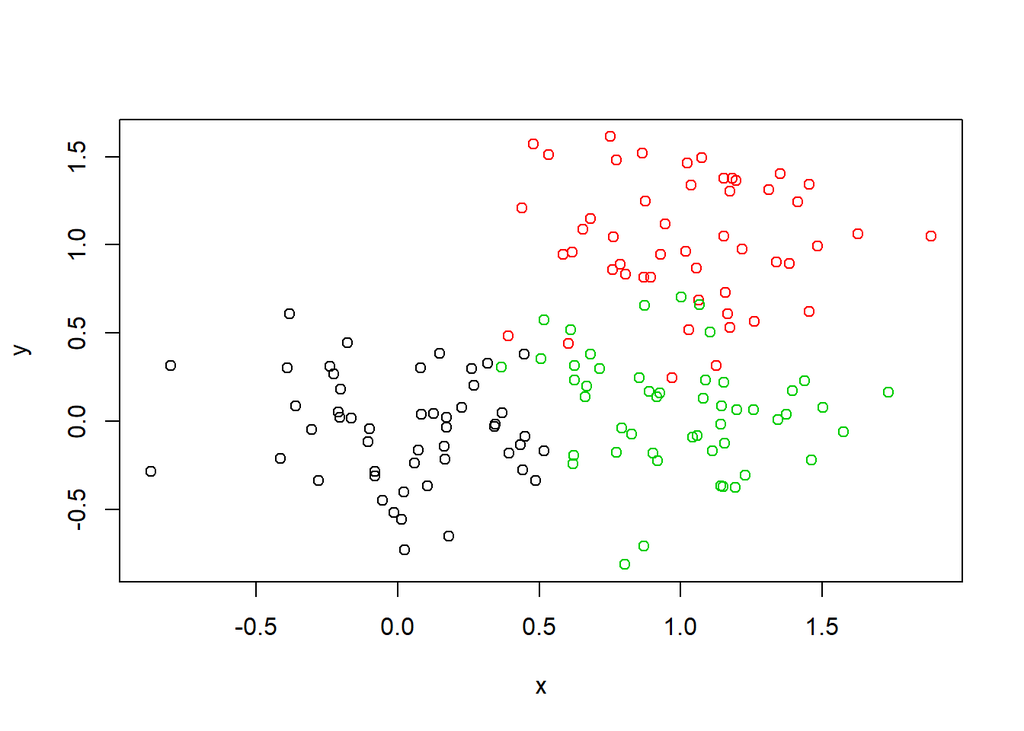

```r
# Step 3. Generate colors for known clusters
# (just so we can compare to hclust results)
col <- as.factor( rep(c("c1","c2","c3"), each=50) )
plot(x, col=col)
```

```r
#How to draw a tree with specifications on where to draw the line for clusters.
dist(x)
```

[output not shown]

[output cut: 3695 more lines]

[output not shown]

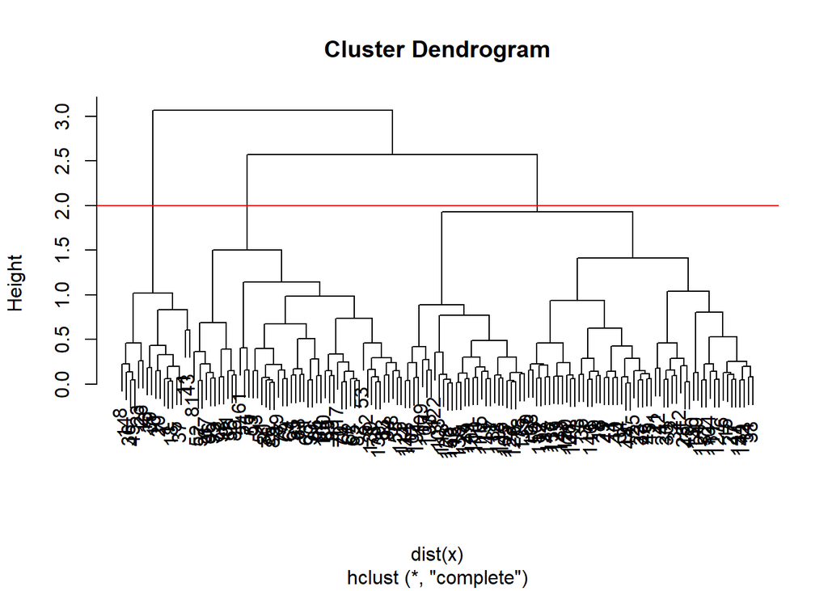

```r
hc2 <- hclust(dist(x))
plot(hc2)
abline(h=2, col="red")
```

```r
grp <- cutree(hc2, k=3)
```

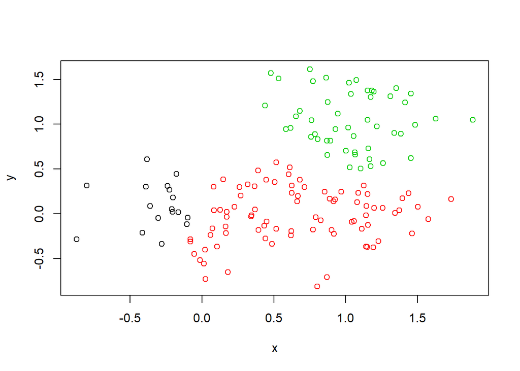

```r
plot(x, col=grp)
```

How many points in each cluster through printing of a table:

```r
table(grp)
```

```
## grp
##  1  2  3
## 17 83 50
```

Cross tablulate i.e. compare the clustering result with known answer. It depicts the known data and see where those data points ended up in terms of which cluster.

```r
table(grp, col)
```

```
##    col
## grp c1 c2 c3
##   1 17  0  0
##   2 33  4 46
##   3  0 46  4
```